# Phishing URL Detection - Hypothesis & EDA

```r
library(tidyverse)
library(scales)
library(ggcorrplot)
library(yardstick)
```

# 1. Problem Statement

## 1.1 Real-world scenario

A user clicks a link in an email, chat, or search result. The corporate proxy has to decide **before the page loads** whether the link is phishing. The cheapest signal at that moment is the URL string itself - no DNS lookup, no HTML fetch, no rendering. If a URL-only check is good enough, we can block the link for free. If it isn’t, we have to fall back to a slower page-level check.

The question is : **how much phishing signal is already in the URL?** If a URL-only model works well enough, it can sit at the front as a fast first-line filter. Where it fails, the slower trust and behavior-level checks have to take over.

The proxy does not output a confidence score - it outputs a block/allow verdict. When a URL classifier produces a probability $p \in [0, 1]$, the standard operating point is to use **threshold 0.5**: classify as phishing if $p >= 0.5$, legitimate if $p < 0.5$.

Explored scenarios for hypothesis driven modeling: 2,3,4

## 1.2 Dataset

The PhiUSIIL dataset has ~235 k rows and 50 predictor features. We split them into three families by how expensive they are to compute:

| Family | What it captures | Example features |
| --- | --- | --- |
| **Lexical** | Properties of the URL string | `URLLength`, `NoOfSubDomain`, `NoOfObfuscatedChar`, `CharContinuationRate` |
| **Trust** | Domain / title consistency | `IsHTTPS`, `HasTitle`, `HasFavicon`, `Bank`, `Pay`, `Crypto` |
| **Behavior** | Page-level content signals | `NoOfURLRedirect`, `NoOfiFrame`, `HasExternalFormSubmit`, `HasHiddenFields` |

# 2. Hypotheses

## H1 (Scenario 2) - The gap between parametric and non-parametric model families is tier-dependent

Phishing URLs usually leave lexical traces: odd subdomain depth, paths full of digits, obfuscated characters. None of this needs the page to be downloaded. A Lexical-only model should still reach a reasonable AUC, but the **size of the gap** between parametric and non-parametric methods should depend on which tier we train on.

We compare three parametric methods (LR, LDA, Naive Bayes) against three non-parametric ones (RF, SVM-RBF, KNN).

Because our project frame is a **corporate-proxy URL phishing detector** , the deployment cost is a single block/allow verdict at threshold 0.5 per click. A model with high AUC but low Specificity creates false blocks, one with low Sensitivity quietly lets phish through. The H1 gating criteria therefore target the **weakest-link operating-point metric** $\mathrm{minSS} = \min(\mathrm{Sensitivity}, \mathrm{Specificity})$ at the default 0.5 cut, with AUC kept as a complementary ranking criterion.

| # | Criterion | Threshold |
| --- | --- | --- |
| C1 | Test-set $\mathrm{minSS}$ gap between the best non-parametric and best parametric model on the **Lexical (URLOnly) tier** | **Δ minSS >= 0.10** |
| C2 | Gradient across tiers in deployment-relevant terms: $\mathrm{minSS}$ gap is **strictly larger** on Lexical than on FullLite | gap(Lexical) > gap(FullLite) |
| C3 | Sanity check on ranking discrimination: mean test AUC gap on Lexical | **ΔAUC >= 0.02** |

H1 is **supported** only if C1 **and** C2 hold - both gated on the deployment metric (minSS at threshold 0.5). C3 is informative but not gating. It confirms the families also differ on the threshold-free metric, but a non-deployable model with a high AUC can’t satisfy the project goal regardless of how it ranks. H1 is **rejected** if either C1 or C2 fails.

Note: The FullLite tier is the replacement for a naive “Full” tier: six Behavior near-leakers are stripped because they push Full to AUC ≈ 1.0 and hide every contrast H1 is trying to measure.

## H2 (Scenario 3) - A smaller URL-only filter can preserve operating quality

Scenario 3 compares feature-selection strategies: one algorithmic method (bidirectional `stepAIC`) and two embedded methods (`lasso`, `elastic-net`).

The primary tier is again **Lexical**, to follow on Scenario 2. FullLite stays as a fallback benchmark, if URL-only is not enough and the proxy must inspect Trust/Behavior signals too. Are we able to shrink the combined filter to a much smaller set without losing AUC, sensitivity, or specificity?

**Scenario 3 H2:** on the Lexical tier, at least one of the three feature-selection methods can produce a compact deployable URL filter with strong held-out operating quality.

| # | Criterion | Threshold |
| --- | --- | --- |
| C1 | Sparsity on the lexical final fit | at least one FS method keeps **=< 9 / 13** predictors (>=30% reduction) |
| C2 | Held-out ranking quality on the same 20% test set | **AUC >= 0.95** |
| C3 | Held-out operating point at threshold 0.5 | **Sensitivity >= 0.94** and **Specificity >= 0.75** |

# 3. Data Loading & Cleaning

```r
# Strip UTF-8 BOM that can appear on the first column name.
raw <- read_csv("PhiUSIIL_Phishing_URL_Dataset.csv", show_col_types = FALSE) %>%
  rename_with(~ str_remove(.x, "^\uFEFF"))
```

```r
# Columns excluded from modeling (identifiers / free text)
ID_COLS <- c("FILENAME", "URL", "Domain", "TLD", "Title")

# Binary target as factor
df <- raw %>%
  mutate(label_bin = factor(label, levels = c(0, 1),
                            labels = c("Legitimate", "Phishing"))) %>%
  select(-all_of(ID_COLS))

# Feature matrix (numeric predictors only)
features <- df %>% select(-label, -label_bin)

cat("Observations:", nrow(df), "\n")
```

```
Observations: 235795
```

```r
cat("Predictors:  ", ncol(features), "\n")
```

```
Predictors:   50
```

## Feature-family mapping

The three families (Lexical / Trust / Behavior) are our own taxonomy, not a property of the dataset. They reflect the cost of obtaining each signal at decision time: Lexical - derivable from the raw URL string alone. Trust - requires light page/domain inspection or an external lookup (DNS, TLD database, HTTPS handshake, title parsing). Behavior - requires fetching, parsing and partially rendering the page.

Note on `IsHTTPS`: although the “https://” scheme is part of the URL string, we place it in the **Trust** family. Modern browsers refuse plain HTTP for any sensitive interaction and warn the user prominently, so the scheme is already enforced by the trust layer of the browser rather than acting as a free lexical clue. Treating it as Lexical would let the URLOnly tier cheat off a binary that is, in practice, a deployment/trust signal.

```r
family_map <- tribble(
  ~feature,                    ~family,
  "URLLength",                 "Lexical",
  "DomainLength",              "Lexical",
  "IsDomainIP",                "Lexical",
  "URLSimilarityIndex",        "Trust",
  "CharContinuationRate",      "Lexical",
  "TLDLegitimateProb",         "Trust",
  "URLCharProb",               "Trust",
  "TLDLength",                 "Lexical",
  "NoOfSubDomain",             "Lexical",
  "HasObfuscation",            "Lexical",
  "NoOfObfuscatedChar",        "Lexical",
  "ObfuscationRatio",          "Lexical",
  "NoOfLettersInURL",          "Lexical",
  "LetterRatioInURL",          "Lexical",
  "NoOfDegitsInURL",           "Lexical",
  "DegitRatioInURL",           "Lexical",
  "NoOfEqualsInURL",           "Lexical",
  "NoOfQMarkInURL",            "Lexical",
  "NoOfAmpersandInURL",        "Lexical",
  "NoOfOtherSpecialCharsInURL","Lexical",
  "SpacialCharRatioInURL",     "Lexical",
  "IsHTTPS",                   "Trust",
  "LineOfCode",                "Behavior",
  "LargestLineLength",         "Behavior",
  "HasTitle",                  "Trust",
  "DomainTitleMatchScore",     "Trust",
  "URLTitleMatchScore",        "Trust",
  "HasFavicon",                "Trust",
  "Robots",                    "Trust",
  "IsResponsive",              "Behavior",
  "NoOfURLRedirect",           "Behavior",
  "NoOfSelfRedirect",          "Behavior",
  "HasDescription",            "Behavior",
  "NoOfPopup",                 "Behavior",
  "NoOfiFrame",                "Behavior",
  "HasExternalFormSubmit",     "Behavior",
  "HasSocialNet",              "Behavior",
  "HasSubmitButton",           "Behavior",
  "HasHiddenFields",           "Behavior",
  "HasPasswordField",          "Behavior",
  "Bank",                      "Trust",
  "Pay",                       "Trust",
  "Crypto",                    "Trust",
  "HasCopyrightInfo",          "Behavior",
  "NoOfImage",                 "Behavior",
  "NoOfCSS",                   "Behavior",
  "NoOfJS",                    "Behavior",
  "NoOfSelfRef",               "Behavior",
  "NoOfEmptyRef",              "Behavior",
  "NoOfExternalRef",           "Behavior"
)
```

## 3.3 Feature Exclusion

To start we drop three groups of features that would bias the analysis or trivialise the modeling. All three decisions are based on what the feature actually means.

### Category 1 - Computed probability / similarity scores

These are not raw URL measurements. They are outputs of other models or expert-written scoring functions that already encode phishing-detection logic. Keeping them would mean we are classifying another classifier’s output, not the URL itself.

```r
SCORES <- c(
  "URLSimilarityIndex",    # similarity to known-phishing URL patterns
  "TLDLegitimateProb",     # P(TLD is legitimate) from an external lookup
  "URLCharProb",           # P(character sequence) from a language model
  "DomainTitleMatchScore", # computed domain-title consistency score
  "URLTitleMatchScore"     # computed URL-title consistency score
)
cat("Computed scores to remove:", paste(SCORES, collapse = ", "), "\n")
```

```
Computed scores to remove: URLSimilarityIndex, TLDLegitimateProb, URLCharProb, DomainTitleMatchScore, URLTitleMatchScore
```

### Category 2 - Redundant binary indicator

`HasObfuscation` is literally `(NoOfObfuscatedChar > 0)`. It holds no information that the count feature doesn’t already carry.

```r
REDUNDANT_BINARY <- "HasObfuscation"
cat("Redundant binary to remove:", REDUNDANT_BINARY, "\n")
```

```
Redundant binary to remove: HasObfuscation
```

### Category 3 - Redundant ratio features

Each ratio below equals `count / URLLength`, and both the count and `URLLength` are already in the dataset. Keeping the ratio gives us a perfect linear dependence and no extra signal.

```r
RATIOS <- c(
  "LetterRatioInURL",      # = NoOfLettersInURL / URLLength
  "DegitRatioInURL",       # = NoOfDegitsInURL / URLLength
  "ObfuscationRatio",      # = NoOfObfuscatedChar / URLLength
  "SpacialCharRatioInURL"  # = NoOfOtherSpecialCharsInURL / URLLength
)
cat("Linearly dependent ratios to remove:", paste(RATIOS, collapse = ", "), "\n")
```

```
Linearly dependent ratios to remove: LetterRatioInURL, DegitRatioInURL, ObfuscationRatio, SpacialCharRatioInURL
```

```r
EXCLUDE_COLS <- c(SCORES, REDUNDANT_BINARY, RATIOS)

df       <- df %>% select(-all_of(EXCLUDE_COLS))
features <- df %>% select(-label, -label_bin)

cat("\nFeatures after exclusion:", ncol(features), "\n")
```

```
Features after exclusion: 40
```

```r
cat("Removed:", paste(EXCLUDE_COLS, collapse = ", "), "\n")
```

```
Removed: URLSimilarityIndex, TLDLegitimateProb, URLCharProb, DomainTitleMatchScore, URLTitleMatchScore, HasObfuscation, LetterRatioInURL, DegitRatioInURL, ObfuscationRatio, SpacialCharRatioInURL
```

Update the family map to reflect the reduced feature set:

```r
family_map <- family_map %>%
  filter(!feature %in% EXCLUDE_COLS)

family_map %>% count(family) %>% print()
```

```
# A tibble: 3 × 2
  family       n
  <chr>    <int>
1 Behavior    20
2 Lexical     13
3 Trust        7
```

## 3.4 Feature Tiers Used in Modeling

```r
tier_lexical  <- family_map %>% filter(family == "Lexical")  %>% pull(feature)
tier_trust    <- family_map %>% filter(family == "Trust")    %>% pull(feature)
tier_behavior <- family_map %>% filter(family == "Behavior") %>% pull(feature)
tier_full     <- c(tier_lexical, tier_trust, tier_behavior)

cat("URLOnly tier (Lexical, ", length(tier_lexical),  " features)\n", sep = "")
```

```
URLOnly tier (Lexical, 13 features)
```

```r
cat("Trust tier              (", length(tier_trust),    " features)\n", sep = "")
```

```
Trust tier              (7 features)
```

```r
cat("Behavior tier           (", length(tier_behavior), " features)\n", sep = "")
```

```
Behavior tier           (20 features)
```

```r
cat("Full tier               (", length(tier_full),     " features)\n", sep = "")
```

```
Full tier               (40 features)
```

# 4. Exploratory Data Analysis

## 4.1 Data Overview

### 4.1.1 Class Balance

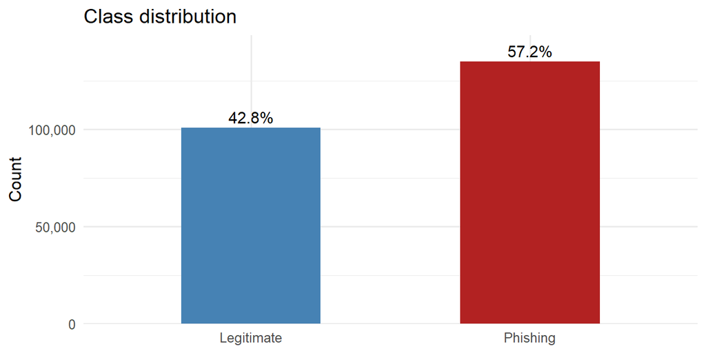

```r
df %>%
  count(label_bin) %>%
  mutate(pct = n / sum(n)) %>%
  ggplot(aes(label_bin, n, fill = label_bin)) +
  geom_col(width = 0.5, show.legend = FALSE) +
  geom_text(aes(label = percent(pct, 0.1)), vjust = -0.4, size = 4) +
  scale_fill_manual(values = c("steelblue", "firebrick")) +
  scale_y_continuous(labels = comma, expand = expansion(mult = c(0, .1))) +
  labs(title = "Class distribution", x = NULL, y = "Count") +
  theme_minimal(base_size = 12)
```

The dataset is roughly balanced, so we don’t need resampling or class-weighting.

### 4.1.2 Missing Values

No missing values are present in any predictor (verified with `colSums(is.na(features))`).

## 4.2 H1 preparation

H1 claims that a URL-only detector (Lexical features) will show a bigger parametric vs. non-parametric gap than any other tier. We don’t test non-linearity directly in the EDA. Instead we show that **per-feature discriminative power is lowest in the Lexical family**.

### 4.2.1 Discriminative Power by Family

For continuous features we use the **standardised mean difference (SMD)** - the gap between class means in SD units. SMD doesn’t work for binary features, so for those we use **Cramér’s V** instead. Both sit on a 0-1 scale, so the two charts are read the same way.

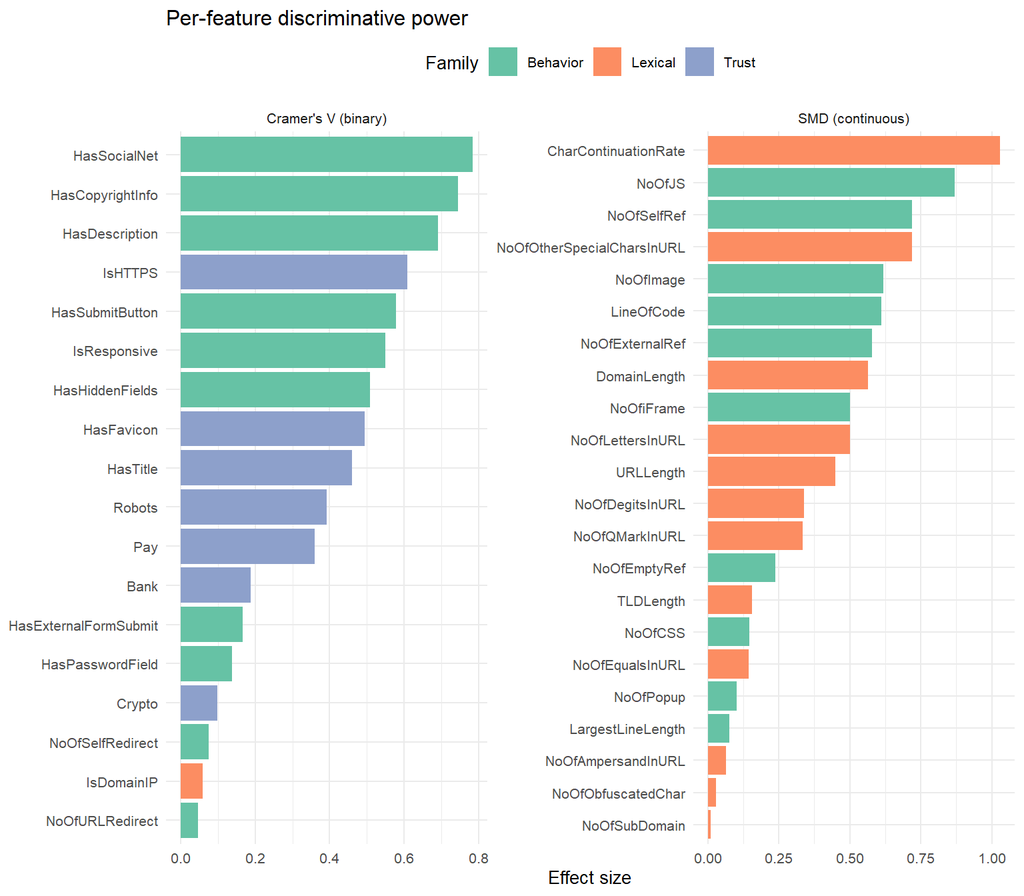

```r
# Continuous features: standardised mean difference.
smd_df <- df %>%
  select(label, all_of(continuous_features)) %>%
  pivot_longer(-label, names_to = "feature", values_to = "value") %>%
  group_by(feature, label) %>%
  summarise(m = mean(value, na.rm = TRUE), s = sd(value, na.rm = TRUE),
            .groups = "drop") %>%
  pivot_wider(names_from = label, values_from = c(m, s),
              names_glue = "{.value}_{label}") %>%
  transmute(
    feature,
    effect = abs(m_1 - m_0) / sqrt((s_0^2 + s_1^2) / 2 + 1e-9),
    metric = "SMD (continuous)"
  )

# Binary features: Cramér's V on a 2x2 contingency table.
cramers_v <- function(x, y) {
  tab <- table(x, y)
  if (any(dim(tab) < 2)) return(NA_real_)
  chi2 <- suppressWarnings(chisq.test(tab, correct = FALSE)$statistic)
  n <- sum(tab)
  as.numeric(sqrt(chi2 / (n * (min(dim(tab)) - 1))))
}

cv_df <- tibble(
  feature = binary_features,
  effect  = map_dbl(binary_features, ~ cramers_v(features[[.x]], df$label)),
  metric  = "Cramer's V (binary)"
)

discrim_df <- bind_rows(smd_df, cv_df) %>%
  left_join(family_map, by = "feature") %>%
  replace_na(list(family = "Other")) %>%
  arrange(desc(effect))

ggplot(discrim_df, aes(x = reorder(feature, effect), y = effect, fill = family)) +
  geom_col() +
  coord_flip() +
  facet_wrap(~ metric, scales = "free", ncol = 2) +
  scale_fill_brewer(palette = "Set2") +
  labs(title = "Per-feature discriminative power",
       x = NULL, y = "Effect size", fill = "Family") +
  theme_minimal(base_size = 10) +
  theme(legend.position = "top")
```

**Takeaway (per-feature view):** The two panels split sharply by family. *Cramér’s V (binary):* every high-effect binary feature is Behavior or Trust - `HasSocialNet`, `HasCopyrightInfo`, `HasDescription`, `IsHTTPS` all sit between 0.6 and 0.8. The only Lexical binary, `IsDomainIP`, is near the bottom at ~0.05. The URL string offers almost no single-flag binary signal. *SMD (continuous):* `CharContinuationRate` is the one Lexical standout at ~1.0, but the rest of the Lexical column clusters lower (`URLLength`, `NoOfDegitsInURL`, `NoOfQMarkInURL` ~0.35-0.5) with a long tail down to ~0.02. Behavior fills the 0.55-0.85 band more densely (`NoOfJS`, `NoOfSelfRef`, `NoOfImage`, `LineOfCode`, `NoOfExternalRef`).

Effect-size distribution per family (continuous features only):

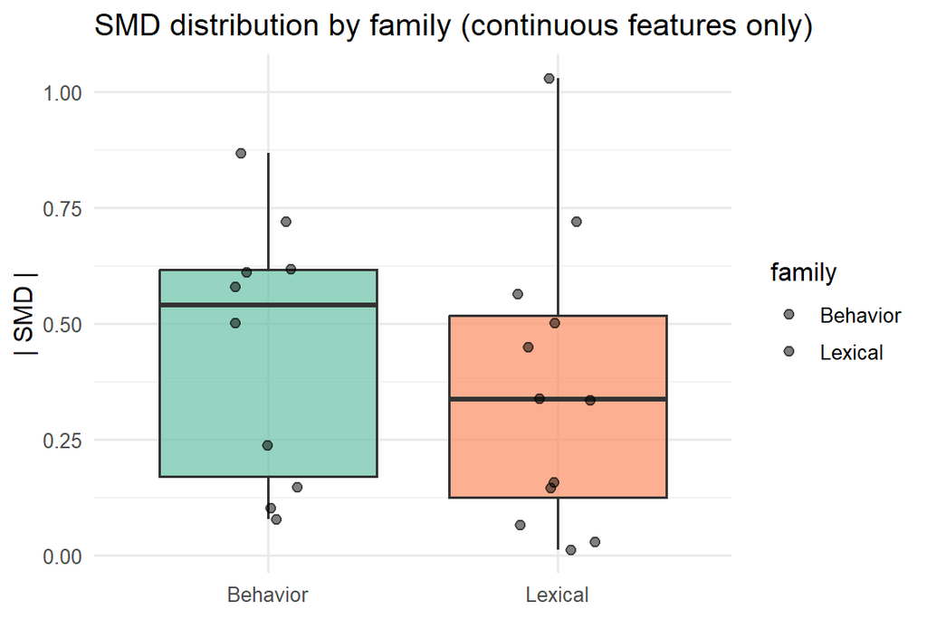

```r
discrim_df %>%
  filter(metric == "SMD (continuous)", family != "Other") %>%
  ggplot(aes(family, effect, fill = family)) +
  geom_boxplot(alpha = 0.7, show.legend = FALSE) +
  geom_jitter(width = 0.15, alpha = 0.5, size = 2) +
  scale_fill_brewer(palette = "Set2") +
  labs(title = "SMD distribution by family (continuous features only)",
       x = NULL, y = "| SMD |") +
  theme_minimal(base_size = 12)
```

**Takeaway (boxplot view):** Only Behavior and Lexical show up - Trust has no continuous features. Lexical’s median |SMD| (~0.33) is lower than Behavior’s (~0.55), and most Lexical features sit in a tighter band. The exception is `CharContinuationRate` near 1.0, which stretches the Lexical range. So the typical Lexical feature is weaker than the typical Behavior feature, with one strong outlier - consistent with H1’s expectation that URL-only models lean on feature combinations rather than single strong predictors.

## 4.3 Collinearity inside Lexical

Lexical features (`URLLength`, `NoOfLettersInURL`, `NoOfDegitsInURL`) measure overlapping URL properties, causing severe collinearity. For linear models (LR, LDA), this makes coefficients numerically unstable. Unregularised LR fails here so we use **Ridge regularisation** to stabilise estimates. Trust and Behavior are mostly uncorrelated binary flags - no collinearity issue there.

### 4.3.1 Lexical Correlation Matrix

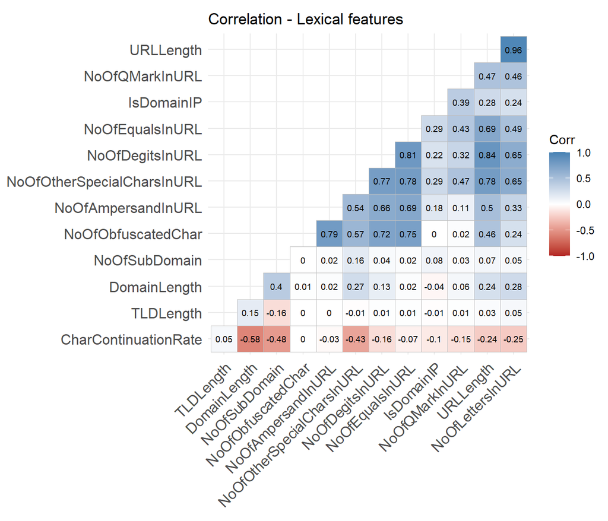

```r
lexical_cor <- features %>%
  select(all_of(tier_lexical)) %>%
  cor(use = "pairwise.complete.obs")

suppressWarnings(
  ggcorrplot(
    lexical_cor,
    type     = "lower",
    hc.order = TRUE,
    lab      = TRUE,
    lab_size = 2.5,
    colors   = c("firebrick", "white", "steelblue"),
    title    = "Correlation - Lexical features"
  )
)
```

### 4.3.2 Variance Inflation Factors

```r
X_vif <- features %>% select(all_of(continuous_features))

# Regress each continuous feature on the remaining continuous features.
vif_df <- tibble(
  feature = names(X_vif),
  vif = map_dbl(names(X_vif), ~ {
    fmla <- reformulate(setdiff(names(X_vif), .x), response = .x)
    1 / (1 - summary(lm(fmla, data = X_vif))$r.squared)
  })
) %>%
  left_join(family_map, by = "feature") %>%
  replace_na(list(family = "Other")) %>%
  mutate(severity = case_when(
    vif > 10 ~ "severe (> 10)",
    vif >= 5 ~ "moderate (5-10)",
    TRUE     ~ "ok (< 5)"
  )) %>%
  arrange(desc(vif))

vif_df %>%
  transmute(Feature = feature,
            Family  = family,
            VIF     = round(vif, 2),
            Severity = severity) %>%
  knitr::kable(caption = "Variance Inflation Factors - continuous features")
```

Variance Inflation Factors - continuous features

| Feature | Family | VIF | Severity |
| --- | --- | --- | --- |
| URLLength | Lexical | 1070.20 | severe (> 10) |
| NoOfLettersInURL | Lexical | 535.40 | severe (> 10) |
| NoOfDegitsInURL | Lexical | 90.60 | severe (> 10) |
| NoOfOtherSpecialCharsInURL | Lexical | 10.16 | severe (> 10) |
| NoOfEqualsInURL | Lexical | 7.94 | moderate (5-10) |
| NoOfObfuscatedChar | Lexical | 4.90 | ok (< 5) |
| NoOfAmpersandInURL | Lexical | 3.18 | ok (< 5) |
| CharContinuationRate | Lexical | 2.77 | ok (< 5) |
| NoOfSelfRef | Behavior | 2.19 | ok (< 5) |
| NoOfExternalRef | Behavior | 1.98 | ok (< 5) |
| NoOfSubDomain | Lexical | 1.95 | ok (< 5) |
| NoOfQMarkInURL | Lexical | 1.86 | ok (< 5) |
| DomainLength | Lexical | 1.80 | ok (< 5) |
| LineOfCode | Behavior | 1.38 | ok (< 5) |
| NoOfImage | Behavior | 1.34 | ok (< 5) |
| NoOfJS | Behavior | 1.13 | ok (< 5) |
| NoOfiFrame | Behavior | 1.11 | ok (< 5) |
| TLDLength | Lexical | 1.11 | ok (< 5) |
| NoOfCSS | Behavior | 1.08 | ok (< 5) |
| NoOfEmptyRef | Behavior | 1.03 | ok (< 5) |
| LargestLineLength | Behavior | 1.01 | ok (< 5) |
| NoOfPopup | Behavior | 1.01 | ok (< 5) |

**Takeaway:** `URLLength`, `NoOfLettersInURL` and `NoOfDegitsInURL` stay near-collinear because they measure overlapping properties of the same URL string. Consequence for modeling:

Unpenalised LR is numerically unstable. Ridge (α = 0) is the minimal fix that bounds the coefficients without collapsing the cluster.

## 4.4 Skewness Assessment *(Scenario 2 preparation)*

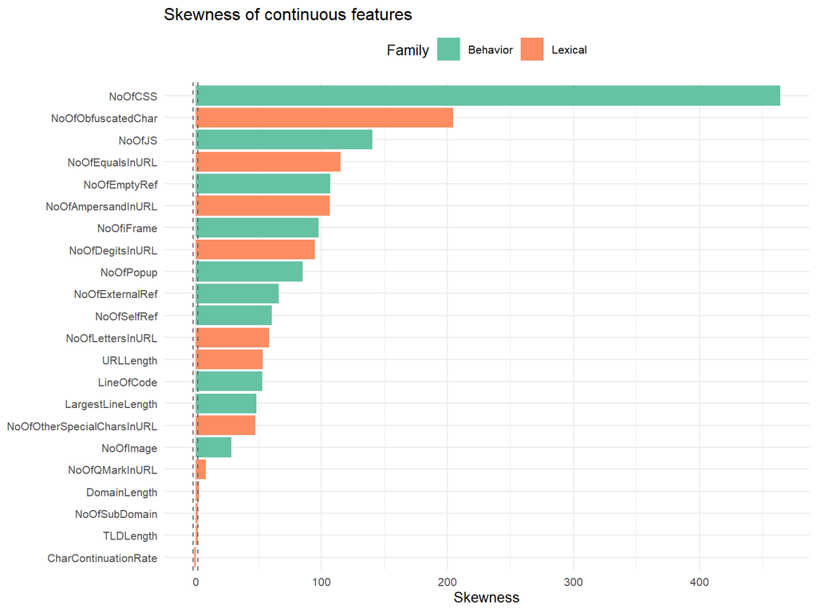

```r
# Skewness for all continuous features
skewness_fn <- function(x) {
  x <- x[!is.na(x)]
  n <- length(x)
  m <- mean(x)
  s <- sd(x)
  (n / ((n-1)*(n-2))) * sum(((x - m) / s)^3)
}

# Apply the same skewness function to every continuous predictor.
skew_df <- features %>%
  select(all_of(continuous_features)) %>%
  summarise(across(everything(), skewness_fn)) %>%
  pivot_longer(everything(), names_to = "feature", values_to = "skewness") %>%
  left_join(family_map, by = "feature") %>%
  replace_na(list(family = "Other")) %>%
  arrange(desc(abs(skewness)))

ggplot(skew_df, aes(reorder(feature, abs(skewness)), skewness, fill = family)) +
  geom_col() +
  coord_flip() +
  geom_hline(yintercept = c(-2, 2), linetype = "dashed", colour = "grey40") +
  scale_fill_brewer(palette = "Set2") +
  labs(title = "Skewness of continuous features",
       x = NULL, y = "Skewness", fill = "Family") +
  theme_minimal(base_size = 10) +
  theme(legend.position = "top")
```

**Takeaway:** Several count features are heavily right-skewed with long outlier tails. This shapes our modeling choices. LR and LDA need scaling and a log-transform on skewed features for the distributional assumption to hold. Trees handle skew without preprocessing. KNN and SVM also tolerate skew, but they still need standardisation since they’re distance-based.

## 4.5 Near-leaker analysis *(Critical for Scenario 2 tier design)*

Six Behavior features are exceptionally discriminative on their own. To understand the scope of the problem for H1, we measure their **univariate AUC** - the discriminative power of each feature in isolation, before any model fitting:

```r
behavior_feats <- family_map %>% filter(family == "Behavior") %>% pull(feature)
label_factor   <- factor(df$label, levels = c(0, 1))

univariate_aucs <- tibble(
  feature = behavior_feats,
  auc = map_dbl(behavior_feats, ~
    roc_auc_vec(
      truth       = label_factor,
      estimate    = features[[.x]],
      event_level = "second"
    )
  )
) %>%
  arrange(desc(auc))

LEAKY_BEHAVIOR <- univariate_aucs %>%
  filter(auc > 0.95) %>%
  pull(feature)

cat("Behavior features ranked by univariate AUC:\n")
```

```
Behavior features ranked by univariate AUC:
```

```r
print(univariate_aucs, n = Inf)
```

```
# A tibble: 20 × 2
   feature                 auc
   <chr>                 <dbl>
 1 LineOfCode            0.990
 2 NoOfExternalRef       0.988
 3 NoOfImage             0.980
 4 NoOfSelfRef           0.972
 5 NoOfJS                0.971
 6 NoOfCSS               0.958
 7 HasSocialNet          0.895
 8 HasCopyrightInfo      0.875
 9 HasDescription        0.846
10 LargestLineLength     0.816
11 HasSubmitButton       0.788
12 IsResponsive          0.768
13 NoOfiFrame            0.755
14 HasHiddenFields       0.749
15 NoOfEmptyRef          0.745
16 NoOfPopup             0.545
17 HasPasswordField      0.542
18 HasExternalFormSubmit 0.535
19 NoOfSelfRedirect      0.485
20 NoOfURLRedirect       0.484
```

```r
cat("\nNear-leakers (univariate AUC > 0.95):\n")
```

```
Near-leakers (univariate AUC > 0.95):
```

```r
cat(paste(LEAKY_BEHAVIOR, collapse = ", "), "\n")
```

```
LineOfCode, NoOfExternalRef, NoOfImage, NoOfSelfRef, NoOfJS, NoOfCSS
```

**The saturation problem.** Phishing pages are usually shallow HTML shells with minimal content, so the six near-leakers-`LineOfCode`, `NoOfExternalRef`, `NoOfImage`, `NoOfSelfRef`, `NoOfJS`, `NoOfCSS`-are nearly perfect phishing signals on their own:

[output not shown]

If we include these six in any tier, any model, parametric or non-parametric reaches AUC ≈ 0.99+ because the signal is so strong, even a simple threshold on a single feature nearly solves the task. —

# 5. EDA Summary & Modeling Implications

After the Section 3.3 exclusions, 40 features remain (13 Lexical + 7 Trust + 20 Behavior). On this reduced set the task is near-perfectly separable as soon as Behavior is included. Six Behavior counts have univariate AUC > 0.95 on their own, so a naive Full tier saturates at AUC ≈ 1.0 and the parametric vs. non-parametric contrast just disappears.

For H1 we therefore use the scenario_2 family layout: Lexical (13), Trust (7), Behavior with the six near-leakers stripped (14), and **FullLite** (34) = Lexical + Trust + reduced Behavior. H1 is tested primarily on the **URLOnly tier**, where the family contrast has the most room to show, and the family gradient (C2) is measured against **FullLite**, not Full.

## 5.1 Implications for modeling scenarios

| Finding | Scenario 2 implication (H1) | Additional EDA implication |
| --- | --- | --- |
| Lexical SMD lowest + features must be combined | Largest parametric/non-parametric AUC gap expected on URLOnly | Feature interactions matter more than single-feature thresholds in URL-only detection |
| Heavy skewness in 19 of 22 continuous features | Log-transform + standardisation for LR/LDA; trees/RF unaffected | Keep one consistent preprocessing recipe across model families for fair comparisons |